# Stats 250: Lab 2 Assignment

Elan Grossman

2023-09-21

### Instructions

Complete the lab exercises and Dive Deeper questions below. Lab exercises will be graded out of 2 points each and the Dive Deeper questions will be graded out of 3 points each - all of them will be graded for *correctness*. Upon completion, follow the submission instructions at the bottom of this document. We strongly encourage you to work on this assignment with a partner.

### Background

The `satscores` data set recorded information from all 50 US states to study the relationship between state-level expenditures on public education and positive student outcomes as measured by SAT scores. For each of the 50 states, data were collected in 2005 on two main variables influencing education expenditures: mean high school teacher pay and mean class size across all secondary schools within a state.

The data contain information on the following variables:

1. `mean.class.size`: average student/teacher ratio in public high schools
2. `mean.salary`: the estimated average annual salary of teachers in public elementary schools
3. `perc.takers`: percentage of all eligible students who actually took the SAT in year data were recorded
4. `mean.SAT`: mean total SAT score for all public school students who took the test
5. `salary.group`: a variable that groups estimated average annual salary into levels (low-wage, medium-wage, well-paid)
6. `class.size.group`: a variable that groups estimated mean high school class size into levels (small, medium, large)
7. `takers.group`: a variable that groups percentage of eligible students who take the SAT as (low, medium, high)

Use the following code chunk to read in the above data set.

```r
load("satscores.rda")
```

And be sure to load in the required packages!

```r
library(ggplot2)
```

```r
head(sat)
```

```
##            mean.class.size mean.salary perc.takers mean.SAT salary.group
## Alabama               17.2      31.144           8     1029     low-wage
## Alaska                17.6      47.951          47      934    well-paid
## Arizona               19.3      32.175          27      944  medium-wage
## Arkansas              17.1      28.934           6     1005     low-wage
## California            24.0      41.078          45      902    well-paid
## Colorado              18.4      34.571          29      980  medium-wage
##            class.size.group takers.group
## Alabama        medium class        small
## Alaska          large class       medium
## Arizona         large class       medium
## Arkansas       medium class        small
## California      large class       medium
## Colorado        large class       medium
```

### Lab Exercises

After reading the background above, complete the following lab exercises. Remember, these exercises are worth 2 points each and are graded for *correctness*.

> 1. Create a histogram that displays the distribution of mean state-level SAT scores. Be sure to appropriately update the plot title and axis labels.

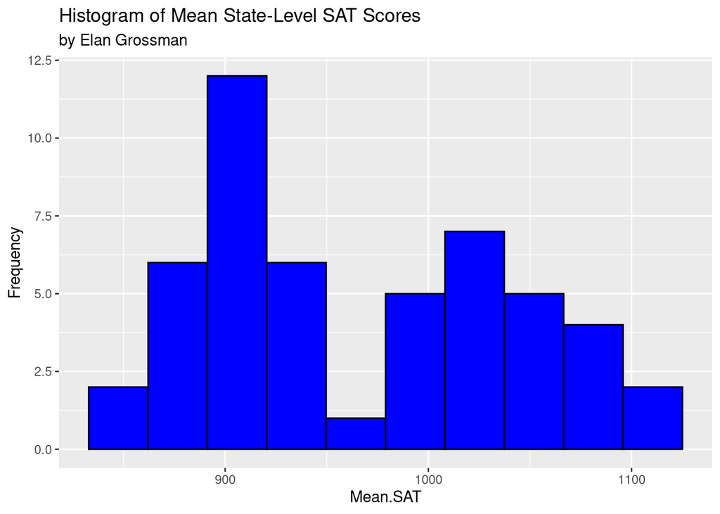

```r
ggplot(data = sat, aes(x = mean.SAT)) +

  geom_histogram(bins = 10,
                 color = "black",
                 fill = "blue") +

  labs(title = "Histogram of Mean State-Level SAT Scores",
       subtitle = "by Elan Grossman",
       x = "Mean.SAT",
       y = "Frequency")
```

> 2. Calculate at least three useful numerical summaries that would help provide a thorough description of this variable’s distribution.

```r
summary(sat$mean.SAT)
```

```
##    Min. 1st Qu.  Median    Mean 3rd Qu.    Max.
##   844.0   897.2   945.5   965.9  1032.0  1107.0
```

```r
mean(sat$mean.SAT)
```

```
## [1] 965.92
```

```r
IQR(sat$mean.SAT)
```

```
## [1] 134.75
```

```r
sd(sat$mean.SAT)
```

```
## [1] 74.82056
```

> 3. Using the histogram from Exercise 1 and the exact numerical values calculated in Exercise 2, thoroughly describe the distribution of mean state-level SAT scores. Your response should be 2 - 3 sentences in length.

*Answer:* The histogram from Exercise 1, the mean state SAT value is a score of 965.92. The distribution is bi modal which shows there is a large standard deviation between scores with a value of 74.821. The range of the scores is 844 to 1107, which demonstrates a large spread for average mean of scores.

> 4. Public policies makers were interested in exploring the following research question: *Is amount that teachers get paid associated with positive high school student outcomes, as measured by the SAT?* To answer this question, create a set of side-by-side boxplots that display mean state-level SAT scores by `salary.group`. Be sure to appropriately update the plot title and axis labels.

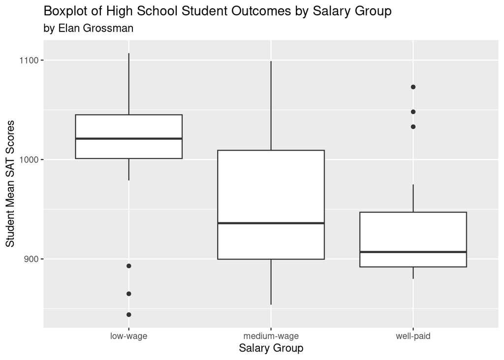

```r
ggplot(data = sat, aes(x = salary.group, y = mean.SAT)) +

  geom_boxplot() +

  labs(title = "Boxplot of High School Student Outcomes by Salary Group",
       subtitle = "by Elan Grossman",
       x = "Salary Group",
       y = "Student Mean SAT Scores")
```

> 5. Use the `aggregate()` function and `summary()` function to compute the mean and five-number summaries of the `mean.SAT` variable for states that provide teachers, on average, with `low-wage`, `medium-wage`, and `well-paid` salaries. Remember, the output will not display in your R Markdown document, but it will show up in the knitted html file.

```r
aggregate(mean.SAT ~ salary.group,
          data = sat,
          FUN = summary)
```

```
##   salary.group mean.SAT.Min. mean.SAT.1st Qu. mean.SAT.Median mean.SAT.Mean
## 1     low-wage      844.0000        1001.0000       1021.0000     1004.1176
## 2  medium-wage      854.0000         899.7500        936.0000      960.2500
## 3    well-paid      880.0000         892.0000        907.0000      933.0588
##   mean.SAT.3rd Qu. mean.SAT.Max.
## 1        1045.0000     1107.0000
## 2        1009.2500     1099.0000
## 3         947.0000     1073.0000
```

```r
##aggregate(mean.SAT ~ salary.group,
     #     data = sat,
     #     FUN = summary)
```

> 6. Using your results from Exercises 4 and 5, write a 3 - 4 sentence conclusion regarding the original question that motivated collection of these data: *Is amount that teachers get paid associated with positive high school student outcomes, as measured by the SAT?*

> 7. In Exercises 4 - 6, you likely observed a surprising relationship between the variables `salary.group` and `mean.sat`. Public policy makers suspected that other variables might be influencing (i.e., confounding) this relationship. On your own, create two stacked barcharts: one barchart should explore the association between `salary.group` and `class.size.group`; the other should explore the association between `salary.group` and `takers.group`. Below the plots, identify which graph you believe shows the *stronger* association between variable pairs. Then, provide a 1 - 2 sentence interpretation of plot.

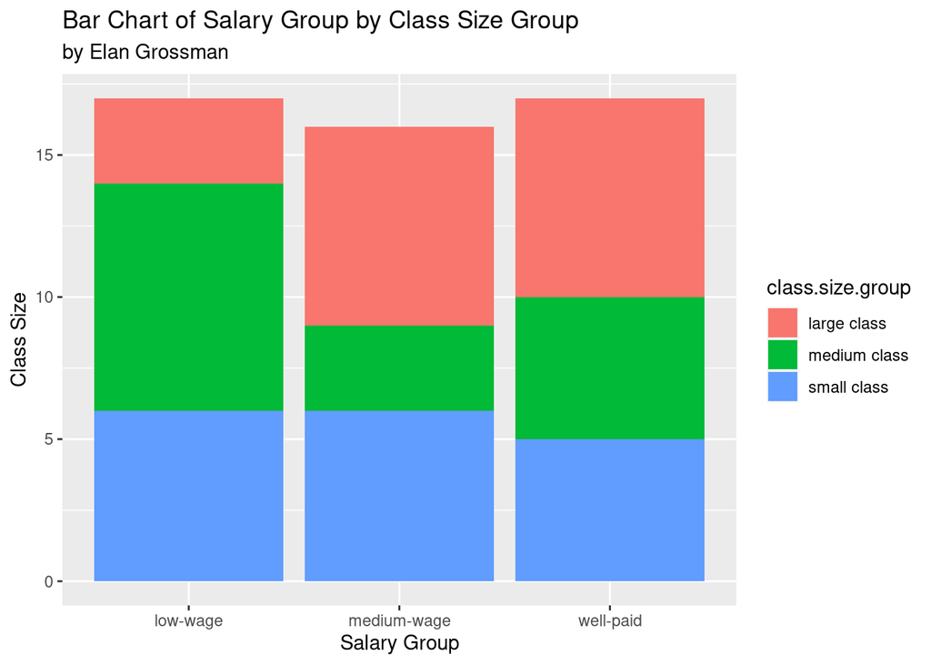

```r
ggplot(data = sat, aes(x = salary.group, fill = class.size.group)) +

  geom_bar() +

  labs(title = "Bar Chart of Salary Group by Class Size Group",
       subtitle = "by Elan Grossman",
       x = "Salary Group",
       y = "Class Size")
```

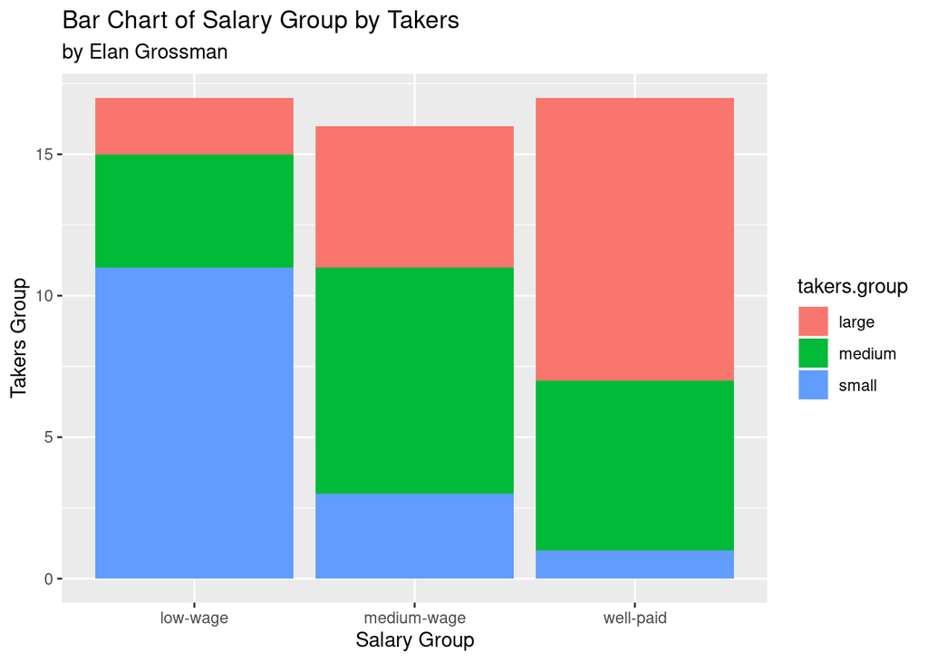

```r
ggplot(data = sat, aes(x = salary.group, fill = takers.group)) +

  geom_bar() +

  labs(title = "Bar Chart of Salary Group by Takers",
       subtitle = "by Elan Grossman",
       x = "Salary Group",
       y = "Takers Group")
```

*Answer:* The association between salary and takers group shows a stronger association between variables. The plots show that the well-paid group also has the highest amount of takers out of the different salary groups, which demonstrates that it is more likely for students to take the exam when their in a well paid salary group.

### Peer Review Practice

Instead of Dive Deeper questions, this section of the lab will focus on how to provide helpful peer feedback. In addition to our short overview in the lab slides, we have provided you with a more detailed document about giving helpful feedback (linked below). After reviewing this document, please complete the following steps:

[ELI Giving Helpful Feedback](https://umich.instructure.com/files/31871661)

1. Read the prompt provided to the student
2. Read the example response provided by the student
3. Provide helpful feedback for the student

Note: this section of the lab will be worth 6 points.

#### Prompt

In order for `takers.group` to be considered a *confounding variable*, it must be shown that it has an association with *both* the explanatory variable (`salary.group`) *and* the response variable (`mean.SAT`). Create a plot, with appropriate labels, that explores the association between `takers.group` and `mean.SAT`. Then, in the space provided, write a conclusion regarding the original research question (below) that incorporates your findings from Exercises 6 and 7.

*Is amount that teachers get paid associated with positive high school student outcomes, as measured by the SAT?*

#### Example Response

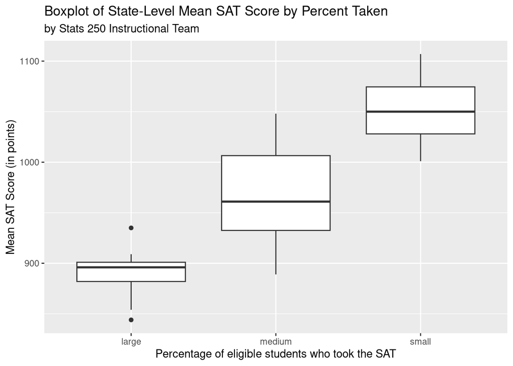

In Exercise 6, we witnessed an interesting pattern that showed that states that pay teachers *less*, on average, tended to have higher mean SAT scores. This relationship was quite surprising, as it contradicted our original expectation that paying high school teachers more would have a positive association with student performance on standardized tests.

In Exercise 7, however, we observed that states which tend to pay teachers a “low wage” were more likely to be in the “small” `takers.group` category. We interpreted this to mean that states that have low teacher wages also tend to be places where only a small subset of students actually take the SAT. In contrast, states that pay teachers handsomely tended to see a much larger percentage of their high school student populations taking the SAT. The plot directly above shows that, when only a small subset of students actually take the SAT, the mean score they get tends to be quite good (likely because the only students who take the SAT are the ones who expect to do well). When a state has a large proportion of its student population take the SAT (perhaps because it is required by law, as is the case in some states), the mean score tends to be much lower. We hypothesize this might be because when nearly ALL students in a state take the SAT, this includes students who aren’t well-prepared for the test, and who wouldn’t take it if they were not required to.

Thus, we can conclude that the percentage of eligible students who take the SAT within a state confounds the relationship between teacher salary and student performance (as measured by the SAT). This is because `takers.group` was shown to have an association with both the explanatory variable in the original research question (`mean.salary`) AND the response variable (`mean.SAT`).

#### Peer Feedback

Offer helpful feedback for the student below. Each component should be 2 - 3 sentences in length. Please consult the “ELI Giving Helpful Feedback” document (linked below) if you need assistance forming your responses.

*Describe:* The point being assesed and proven through this plot is whether the percentage of eligible students who take the SAT within a state confunds the relationship between teacher salary and student performance. According to the box plot above, it is clear that the percentage of students who take the test does confound the relationship between teacher salary and student performance. Your purpose seems to describe the reason for the difference between exercise 6 and 7, providing a reason that explains how the outcomes of exercise 6 contradicts our original expectation that paying high school teachers more would have a positive impact on student performance on SATs, while in exercise 7, we observed that states which tend to pay leachers less were more likely to be in the smaller taker group, rpoving why the data in exercise 7 contradicted the orginal assumption.

*Evaluate:* This information and claim is accurate, and the clarity of the presentation makes everything straightforward and apparent.The writing and conveyed message was cohesive and the evidence was ordered and present to keep the reader informed and interested.

*Suggest:* Going forward, I would suggest that you would use the titles of the plots rather than referring to them as their location on the assignment. This would make it much more clear for readers to follow the information and double check the plots based on your evidence.

### Submission Instructions

Once you have finished, follow the instructions below to submit your work.

1. At the top of the document, update the `author` field. Do not change anything else at the top of the document.
2. Click the Knit button to create an HTML file of your work.
3. In the Files pane (bottom right window), check the box next to `lab02_assignment.html`.
4. In the Files pane, click on the gear icon (More) and select “Export…”
5. Do not change the file name (`lab02_assignment.html`). Click Download and save the file to your computer.
6. On the Stats 250 Canvas site, navigate to the Lab 1 assignment.
7. Upload your saved `lab02_assignment.html` file.
8. Click “Submit Assignment”. Congratulations, you are done with Lab 2!